# NVTA_Results

Volpe Center (Sarah Lohmar, Dan Flynn, Eric Englin)

6/24/2021

## Intial Findings

The Volpe team started by looking at the daily VMT for all scenarios. This is done by combining seven DVMT outputs by location and type of mode.

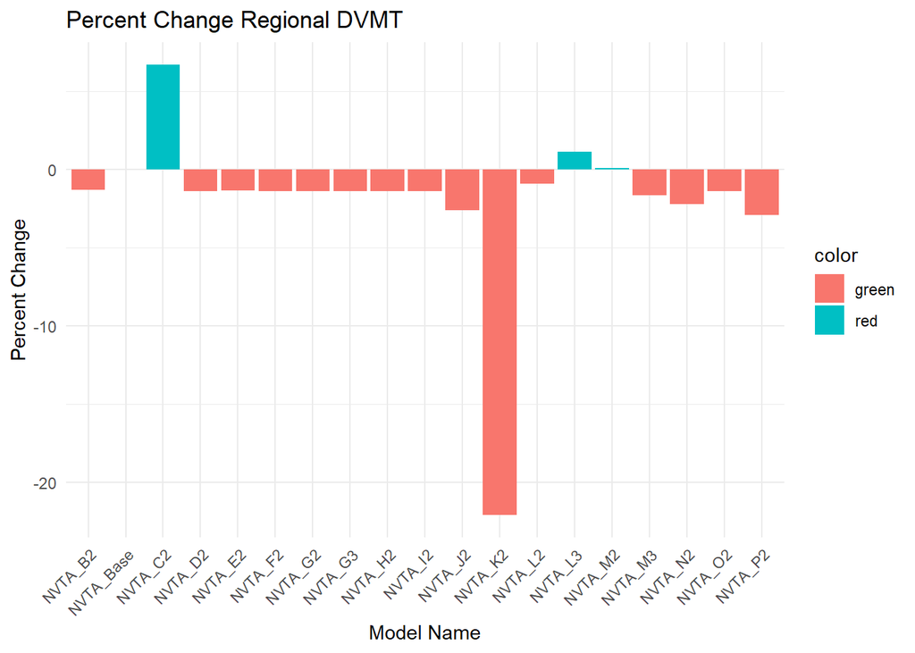

## Validation

The Volpe team also realized the need to validate the VisionEval output.

#### MWCOG DVMT

The VDOT team sent along daily VMT values in 2021 and 2045 from the MWCOG MOE Base model. These results include household car VMT, business car VMT, and car travel from other locations (such as motorists who live outside the area and are passing through it.

Here are the raw results from the MWCOG base model in 2045:

| Jurisdiction | Freeway | Expressway | Major Art. | Minor Art. | Collector | Ramp | All |
| --- | --- | --- | --- | --- | --- | --- | --- |
| Fairfax County | 12,517,806 | 5,910,760 | 6,219,736 | 1,419,677 | 1,256,563 | 488,882 | 27,813,424 |
| City of Fairfax | 0 | 284,867 | 99,406 | 9,144 | 0 | 0 | 393,417 |
| Falls Church | 0 | 106,172 | 40,693 | 4,605 | 0 | 0 | 151,470 |

CROSSTAB ROW=FLAG COL=FTYPE VAR=_24VMTTRK

| Jurisdiction | Freeway | Expressway | Major Art. | Minor Art. | Collector | Ramp | All |
| --- | --- | --- | --- | --- | --- | --- | --- |
| Fairfax County | 3,071,425 | 988,206 | 919,784 | 212,966 | 331,425 | 90,603 | 5,614,408 |
| City of Fairfax | 0 | 37,640 | 12,957 | 774 | 0 | 0 | 51,371 |
| Falls Church | 0 | 18,944 | 5,575 | 425 | 0 | 0 | 24,944 |

When you add all of the numbers up, you get 34,049,034 daily VMTs. This is about 4,000,000 higher than the VisionEval dvmt values. The chart below shows the percent differences with each of our scenarios.

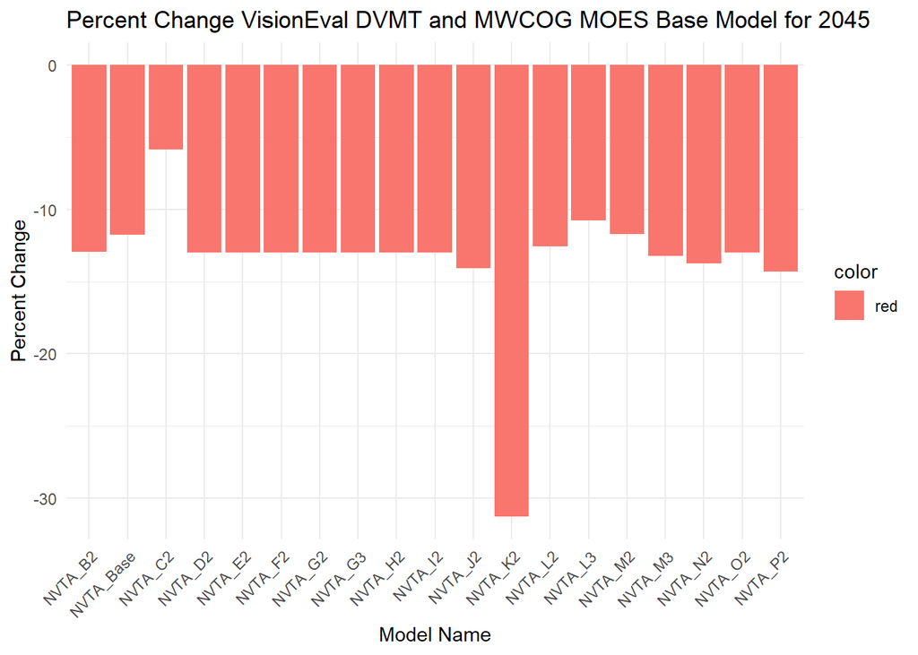

Here is a table showing some of the validation steps taken:

| File from the Travel Demand Model | Value | Output from NOVA model | Output from VisionEval (Base Model) | Percent Difference |
| --- | --- | --- | --- | --- |
| 2019i4_Trip_Generation_Summary.txt | HH DVMT | 34,049,034 | 30,040,347 | 5-15% |
| 2019i4_Trip_Generation_Summary.txt | Truck DVMT | 5,690,723 | 1,206,452 | 70-80% |